# A Portfolio of Exercises in Spatial Analysis

Akiva Blander

In this portfolio, I’ve collated maps that I’ve created in the last 6 weeks that are based in four cities where I’ve spent a significant amount of time: Boston, Philadelphia, San Francisco, and New York City, where I was born and raised. I’ve sought to represent clear spatial patterns in how many American cities are organized, with respect to climate, socioeconomics, distribution of key sites, and issues of accessibility.

Cumulatively, the following maps demonstrate a familiarity with creating and displaying both vector and raster layers; representing relationships among point and polygon layers; the process of georeferencing; and developing and displaying accessibility data in a range of formats.

# Maps of Boston

Here are two maps of Boston. They contain several vector layers, including some newly created ones that are based on calculating features of existing layers.

## How are charging stations and historic districts distributed throughout the city?

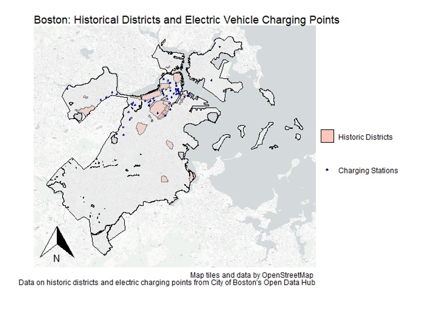

## Which historic districts contain charging stations?

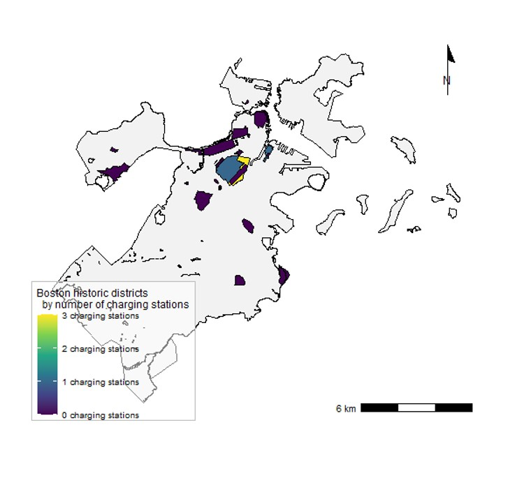

# Maps of Philadelphia

Here are three maps of Philadelphia. These maps are themed around accessibility in the city; specifically, they calculate and display accessibility - in minutes and as a score - to destinations including banks and transit stops.

## How long does it take for residents to reach one of 100-odd city-listed banks?

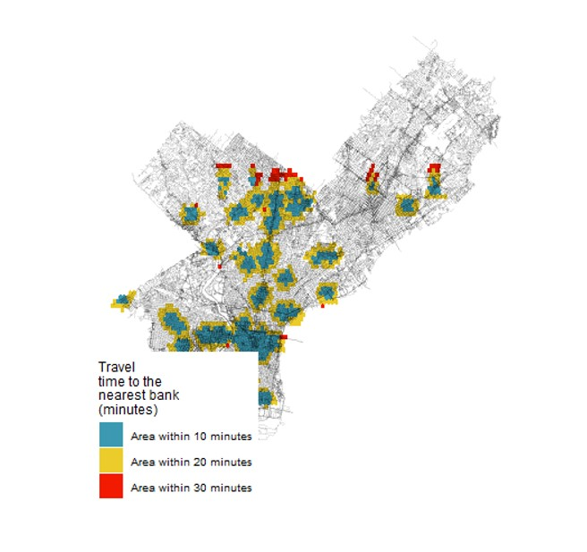

## How long does it take for residents to reach transit stations throughout the city?

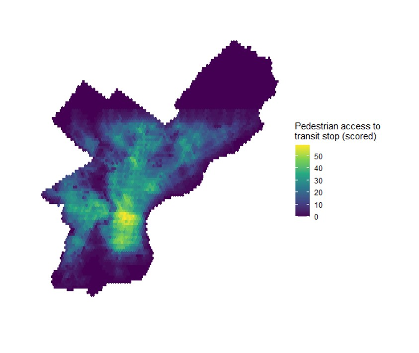

This map shows similar accessibility data in Philadelphia, but in a finer-grain raster layer.

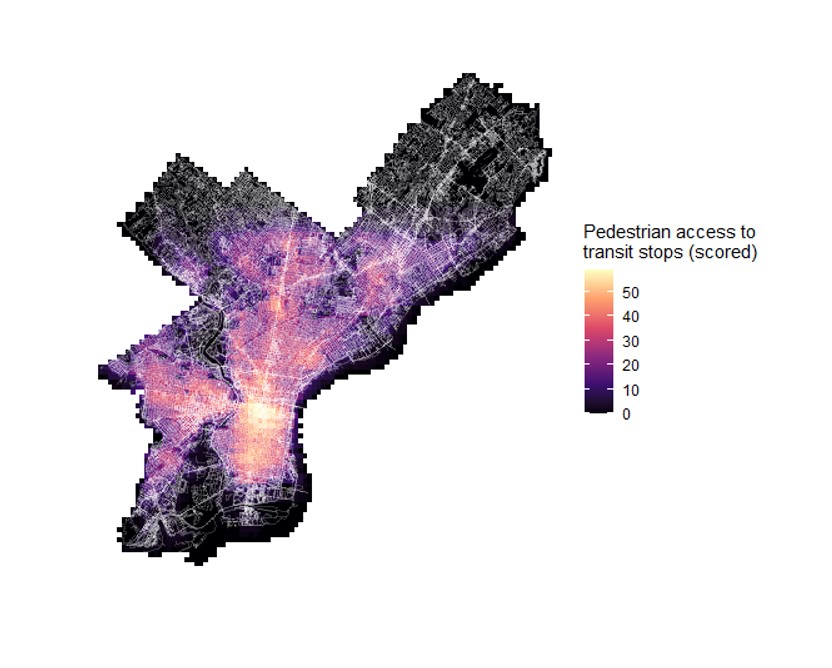

# Maps of New York City

Here are two maps of Lower Manhattan, one with and one without a georeferenced historic map (raster layer) from the 1850s. One interesting theme that emerges is that of continuity and change: The area retains its historic core character, but a changing coastline and constellation of greenspaces reveal an ongoing challenge.

## What are some relevant vector layers that can help illuminate some spatial and social patterns in Lower Manhattan?

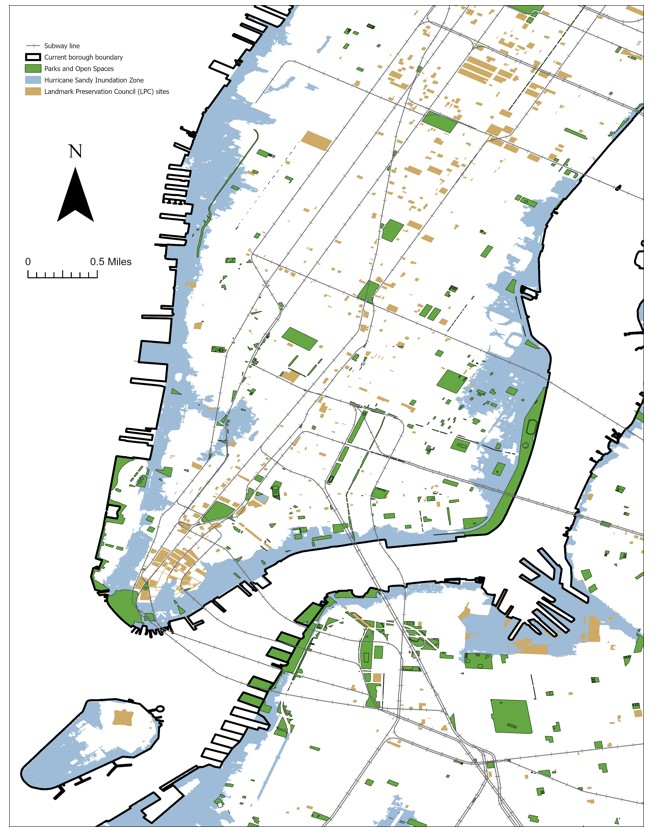

## How does introducing the historic map of Lower Manhattan - or overlaying raster and vector layers - enrich our understanding of these themes?

[figure not shown]

# An interactive map of food stamps dependence in San Francisco

This interactive map displays American Community Survey data from 2019 at the level of block group. It shows slightly higher reliance on food stamps or other forms of supplemental income around the downtown area, while the more residential areas on the west side of the city are recipients at a lower level. Due to the large size and likely low population of certain block groups (in Golden Gate Park, the Presidio, etc.), some polygons don’t give a good sense of social need.

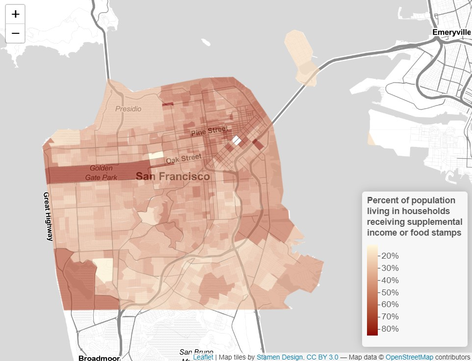